# 1. Data Description

```
Enter age: 40
```

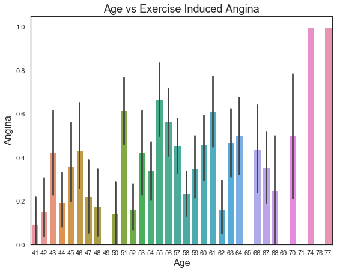

```python
HD.loc[HD['exercise_induced_angina'] == 'Have', 'exercise_induced_angina'] = 1
HD.loc[HD['exercise_induced_angina'] == 'Not_Have', 'exercise_induced_angina'] = 0

AGE=int(input('Enter age: '))
age1=HD[HD.Age>AGE]
plt.figure(figsize=(9,7))
sns.barplot(age1.Age,age1.exercise_induced_angina)
plt.title('Age vs Exercise Induced Angina',fontsize=18)
plt.xlabel('Age',fontsize=16)
plt.ylabel('Angina',fontsize=16)
plt.show()

HD.loc[HD['exercise_induced_angina'] == 1, 'exercise_induced_angina'] = 'Have'
HD.loc[HD['exercise_induced_angina'] == 2, 'exercise_induced_angina'] = 'Not_Have'
```

```python
HD[HD.Age==49][['Age','exercise_induced_angina']]
```

|  | Age | exercise_induced_angina |
| --- | --- | --- |
| 53 | 49 | 0 |
| 81 | 49 | 0 |
| 215 | 49 | 0 |
| 226 | 49 | 0 |
| 234 | 49 | 0 |
| 236 | 49 | 0 |
| 400 | 49 | 0 |
| 451 | 49 | 0 |
| 453 | 49 | 0 |
| 515 | 49 | 0 |
| 518 | 49 | 0 |
| 618 | 49 | 0 |
| 631 | 49 | 0 |
| 761 | 49 | 0 |
| 835 | 49 | 0 |
| 939 | 49 | 0 |
| 956 | 49 | 0 |

```
Enter age: 44
```

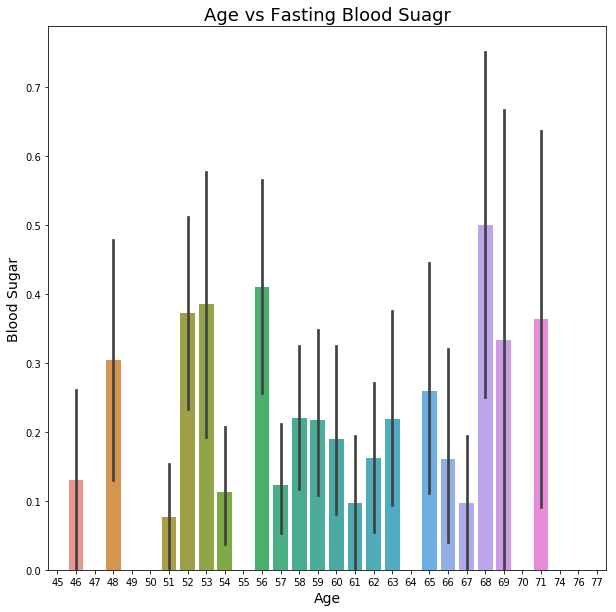

```python
HD.loc[HD['fasting_blood_sugar'] == 'Have', 'fasting_blood_sugar'] = 1
HD.loc[HD['fasting_blood_sugar'] == 'Not_Have', 'fasting_blood_sugar'] = 0

AGE=int(input('Enter age: '))                      # age as input
age1=HD[HD.Age>AGE]
plt.figure(figsize=(10,10))
sns.barplot(age1.Age,age1.fasting_blood_sugar)
plt.title('Age vs Fasting Blood Suagr',fontsize=18)
plt.xlabel('Age',fontsize=14)
plt.ylabel('Blood Sugar',fontsize=14)
plt.show()

HD.loc[HD['fasting_blood_sugar'] == 1, 'fasting_blood_sugar'] = 'Have'
HD.loc[HD['fasting_blood_sugar'] == 0, 'fasting_blood_sugar'] = 'Not_Have'
```

```
Enter age: 50
```

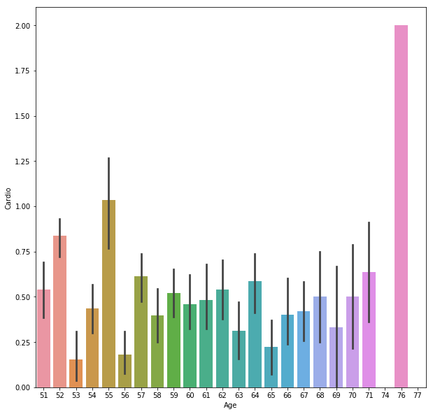

```python
AGE=int(input('Enter age: '))                      # age as input
age1=HD[HD.Age>AGE]
plt.figure(figsize=(10,10))
sns.barplot(age1.Age,age1.resting_cardiographic_results)
plt.xlabel('Age')
plt.ylabel('Cardio')
plt.show()
```

```
Enter age: 40
```

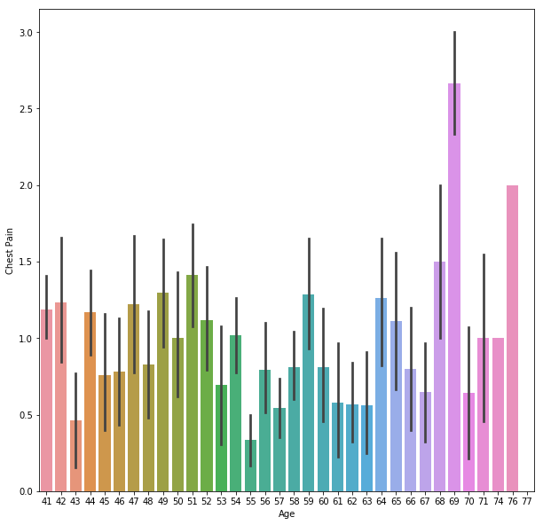

```python
HD.loc[HD['Chest_pain_type'] == 'typical angina', 'Chest_pain_type'] = 0
HD.loc[HD['Chest_pain_type'] == 'atypical angina', 'Chest_pain_type'] = 1
HD.loc[HD['Chest_pain_type'] == 'non-anginal pain', 'Chest_pain_type'] = 2
HD.loc[HD['Chest_pain_type'] == 'asymptomatic', 'Chest_pain_type'] = 3

AGE=int(input('Enter age: '))                      # age as input
age1=HD[HD.Age>AGE]
plt.figure(figsize=(10,10))
sns.barplot(age1.Age,age1.Chest_pain_type)
plt.xlabel('Age')
plt.ylabel('Chest Pain')
plt.show()

HD.loc[HD['Chest_pain_type'] == 0, 'Chest_pain_type'] = 'typical angina'
HD.loc[HD['Chest_pain_type'] == 1, 'Chest_pain_type'] = 'atypical angina'
HD.loc[HD['Chest_pain_type'] == 2, 'Chest_pain_type'] = 'non-anginal pain'
HD.loc[HD['Chest_pain_type'] == 3, 'Chest_pain_type'] = 'asymptomatic'
```

```python
sns.set(style="darkgrid")
```

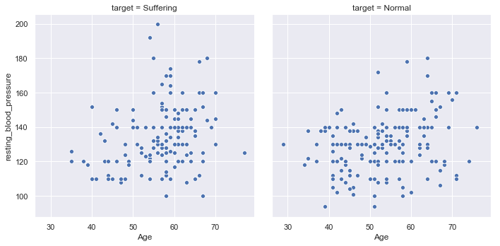

```python
sns.relplot(x="Age",y="resting_blood_pressure",col='target', data=HD)
```

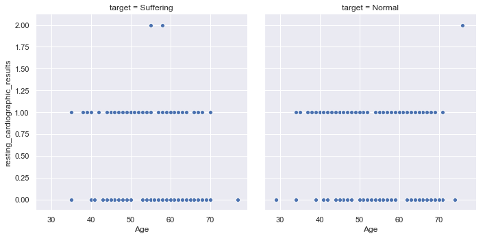

```python
sns.relplot(x="Age", y="resting_cardiographic_results", col='target', data=HD)
```

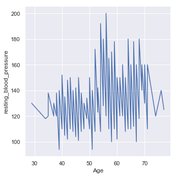

```python
g = sns.relplot(x="Age", y="resting_blood_pressure", kind="line",estimator=None,data=HD)
```

## How much is the Resting Blood Pressure and Chest Pain Type having different Age and Sex people either Suffering or not Suffering from Heart Disease?

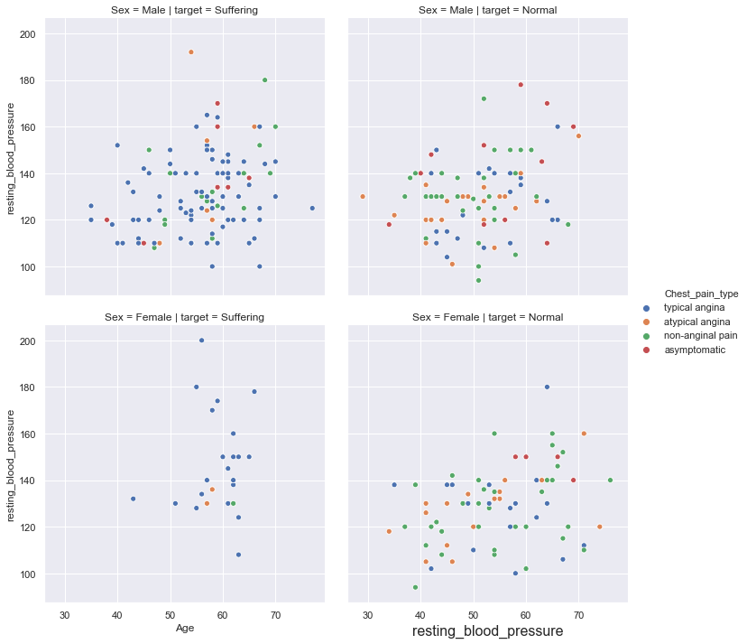

```python
fig=plt.figure(figsize=(15,15))
sns.relplot(x="Age",y="resting_blood_pressure",hue='Chest_pain_type', col='target', row='Sex', data=HD)
plt.xlabel('Age',fontsize=16)
plt.xlabel('resting_blood_pressure',fontsize=16)
sns.set(style="white")
```

## How much is the Resting Blood Pressure and Chest Pain Type of different Age and Sex people either Suffering or not Suffering from Heart Disease and having Fasting Blood Sugar or Not?

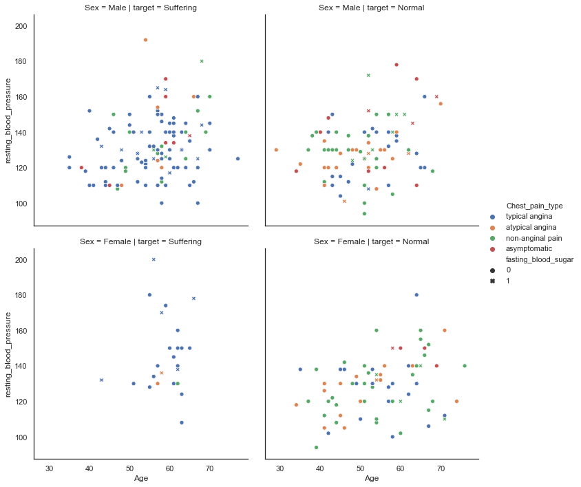

```python
fig=plt.figure(figsize=(50,50))
sns.relplot(x="Age",y="resting_blood_pressure",hue='Chest_pain_type',style='fasting_blood_sugar', row='Sex', col='target', data=HD)
sns.set(style="white")
```

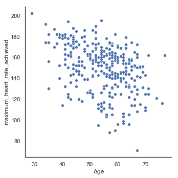

```python
sns.relplot(x="Age",y="maximum_heart_rate_achieved", data=HD)
```

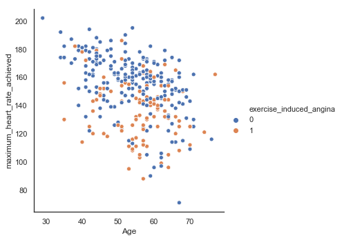

```python
sns.relplot(x="Age",y="maximum_heart_rate_achieved",hue='exercise_induced_angina', data=HD)
```

## How much is the Maximum Heart Rate Achieved ,Exercise Induced Angina and Chest Pain Type of different Age and Sex people either Suffering or not Suffering from Heart Disease?

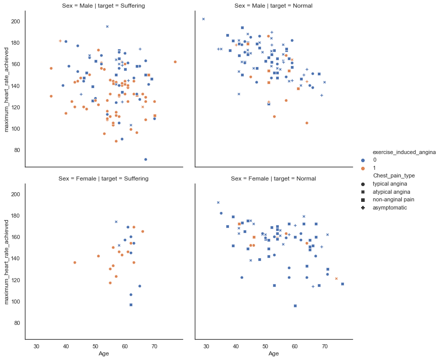

```python
sns.relplot(x="Age",y="maximum_heart_rate_achieved",hue='exercise_induced_angina',style='Chest_pain_type',col='target', row='Sex', data=HD)
```

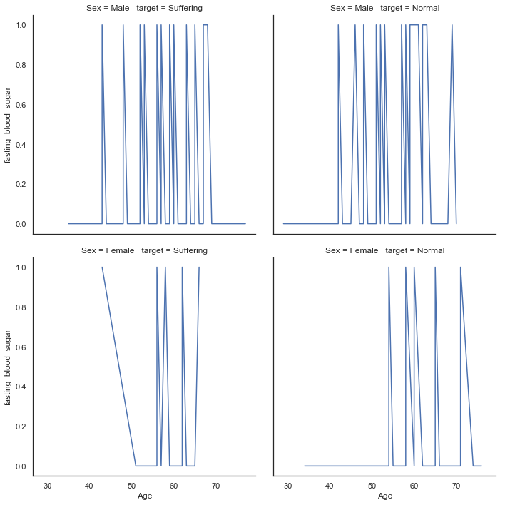

```python
sns.relplot(x="Age", y="fasting_blood_sugar",estimator=None, kind='line', row='Sex', col='target',data=HD)
```

# 3.2 Sex(Gender)DataAnalysis

## What is the count and percentage of male and female for given datset?

```python
total_genders_count=len(HD.Sex)
male_count=len(HD[HD['Sex']=='Male'])
female_count=len(HD[HD['Sex']=='Female'])
print('Total Genders :',total_genders_count)
print('Male Count    :',male_count)
print('Female Count  :',female_count)
```

```
Total Genders : 1025
Male Count    : 713
Female Count  : 312
```

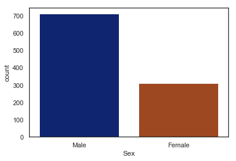

```python
sns.countplot(HD.Sex,palette=("dark"))
plt.show()
```

```python
x=male_count / (total_genders_count)*100
y=female_count / (total_genders_count)*100
```

```python
#Percentage ratios
print("Male State: {:.2f}%".format((male_count / (total_genders_count)*100)))
print("Female State: {:.2f}%".format((female_count / (total_genders_count)*100)))
```

```
Male State: 69.56%
Female State: 30.44%
```

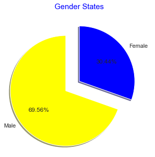

```python
colors = ['yellow','blue']
plt.figure(figsize = (5,5))
plt.pie([x,y],labels=['Male','Female'],colors=colors,explode =(0.3,0),startangle=90,shadow=True,autopct='%1.2f%%')
plt.title('Gender States',color = 'blue',fontsize = 15)
plt.show()
```

## Who have higher cholesterol,Male or Female?

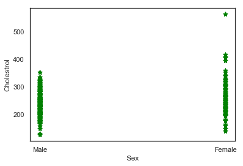

```python
# scatter plot between sex and cholestrol
plt.scatter(HD['Sex'],HD['cholestoral'],color='green',marker = "*",s=50)
plt.xlabel("Sex")
plt.ylabel("Cholestrol")
plt.show()
```

## What is the count and percentage of male and female, who is suffering from hert disease or not?

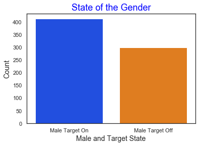

```python
#Now, we are going to analyze both the sex and the heart health situation.
#Male State & target Male & Female
male_andtarget_off=len(HD[(HD.Sex=='Male')&(HD['target']=='Normal')])
male_andtarget_on=len(HD[(HD.Sex=='Male')&(HD['target']=='Suffering')])
sns.barplot(x=['Male Target On','Male Target Off'],y=[male_andtarget_on,male_andtarget_off],palette='bright')
plt.xlabel('Male and Target State',fontsize=14)
plt.ylabel('Count',fontsize=14)
plt.title('State of the Gender',fontsize=18,color='blue')
plt.show()
```

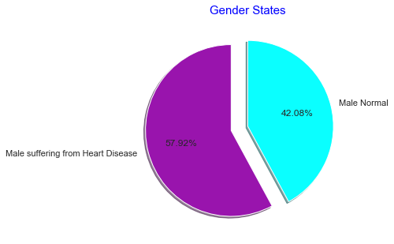

```python
colors = ['#9914AD','#0AFFFF']
plt.figure(figsize = (5,5))
plt.pie([male_andtarget_on,male_andtarget_off],labels=['Male suffering from Heart Disease ','Male Normal'],colors=colors,explode =(0.2,0),startangle=90,shadow=True,autopct='%1.2f%%')
plt.title('Gender States',color = 'blue',fontsize = 15)
plt.show()
```

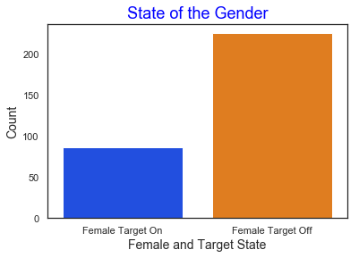

```python
female_andtarget_off=len(HD[(HD.Sex=='Female')&(HD['target']=='Normal')])
female_andtarget_on=len(HD[(HD.Sex=='Female')&(HD['target']=='Suffering')])
sns.barplot(x=['Female Target On','Female Target Off'],y=[female_andtarget_on,female_andtarget_off],palette='bright')
plt.xlabel('Female and Target State',fontsize=14)
plt.ylabel('Count',fontsize=14)
plt.title('State of the Gender',fontsize=18,color='blue')
plt.show()
```

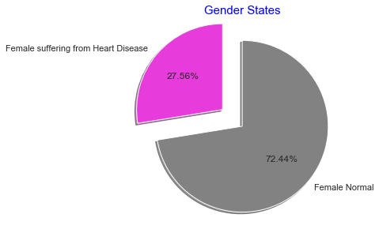

```python
colors = ['#E83BDC','#828282']
plt.figure(figsize = (5,5))
plt.pie([female_andtarget_on,female_andtarget_off],labels=['Female suffering from Heart Disease ','Female Normal'],colors=colors,explode =(0.3,0),startangle=90,shadow=True,autopct='%1.2f%%')
plt.title('Gender States',color = 'blue',fontsize = 15)
plt.show()
```

# 3.3 AgeRangeAnalysis

```python
HD['AgeRange']=0
youngAge_index=HD[(HD.Age>=29)&(HD.Age<40)].index
middleAge_index=HD[(HD.Age>=40)&(HD.Age<=55)].index
elderlyAge_index=HD[(HD.Age>55)].index
```

```python
for index in elderlyAge_index:
    HD.loc[index,'AgeRange']='Elder_Age'

for index in middleAge_index:
    HD.loc[index,'AgeRange']='Middle_Age'

for index in youngAge_index:
    HD.loc[index,'AgeRange']='Young_Age'
```

## What is the percentage of people Suffering and Not Suffering in YoungAge,MiddleAge and ElderAge?

```python
Suffering_youngAge=len(HD[(HD.target=='Suffering')&(HD.AgeRange=='Young_Age')])
Normal_youngAge=len(HD[(HD.target=='Normal')&(HD.AgeRange=='Young_Age')])
```

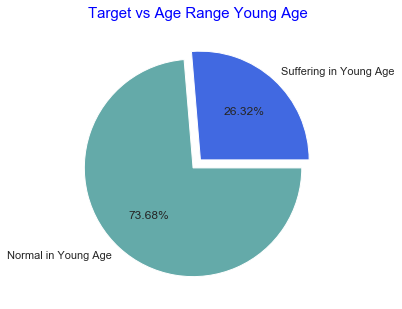

```python
colors = ['royalblue','#64AAA9']
explode = [0,0.1]
plt.figure(figsize = (5,5))
plt.pie([Suffering_youngAge,Normal_youngAge], explode=explode, labels=['Suffering in Young Age','Normal in Young Age'], colors=colors, autopct='%1.2f%%')
plt.title('Target vs Age Range Young Age ',color = 'blue',fontsize = 15)
plt.show()
```

```python
suffering_middleAge=len(HD[(HD.target=='Suffering')&(HD.AgeRange=='Middle_Age')])
Normal_middleAge=len(HD[(HD.target=='Normal')&(HD.AgeRange=='Middle_Age')])
```

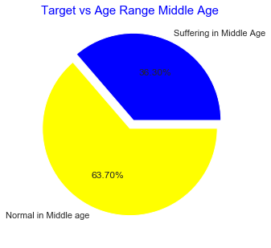

```python
colors = ['blue','yellow']
explode = [0.1,0]
plt.figure(figsize = (5,5))
plt.pie([suffering_middleAge,Normal_middleAge], explode=explode, labels=['Suffering in Middle Age','Normal in Middle age'], colors=colors, autopct='%1.2f%%')
plt.title('Target vs Age Range Middle Age',color = 'blue',fontsize = 15)
plt.show()
```

```python
suffering_elderAge=len(HD[(HD.target=='Suffering')&(HD.AgeRange=='Elder_Age')])
Normal_elderAge=len(HD[(HD.target=='Normal')&(HD.AgeRange=='Elder_Age')])
```

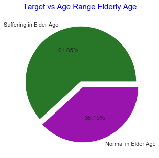

```python
colors = ['#287728','#9914AD']
explode = [0,0.1]
plt.figure(figsize = (5,5))
plt.pie([suffering_elderAge,Normal_elderAge], explode=explode, labels=['Suffering in Elder Age','Normal in Elder Age'], colors=colors, autopct='%1.2f%%')
plt.title('Target vs Age Range Elderly Age ',color = 'blue',fontsize = 15)
plt.show()
```

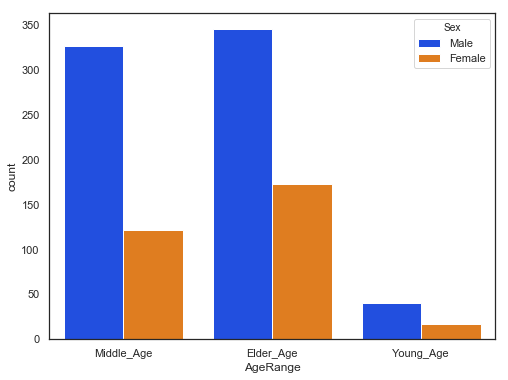

```python
fig=plt.figure(figsize=(8,6))
sns.countplot(HD.AgeRange,hue=HD.Sex,palette='bright')
plt.show()
```

# 3.4 ChestPainDataAnalysis

## How many people(Male & Female) are affected by Typical , Atypical , Non-anginal , Asymptomatic Angina?

```python
HD.Chest_pain_type.value_counts()
```

```
typical angina      497
non-anginal pain    284
atypical angina     167
asymptomatic         77
Name: Chest_pain_type, dtype: int64
```

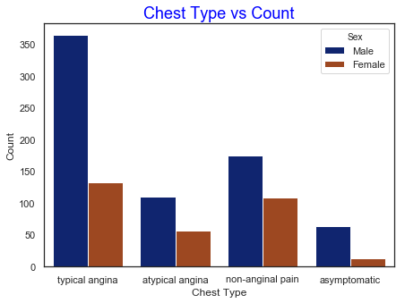

```python
plt.figure(figsize = (7,5))
sns.countplot(HD.Chest_pain_type,hue=HD.Sex,palette='dark')
plt.xlabel('Chest Type')
plt.ylabel('Count')
plt.title('Chest Type vs Count',fontsize=18,color='blue')
plt.show()
```

## What is the count and percentage of Male & Female are suffering from different types of Angina and Heart Disease?

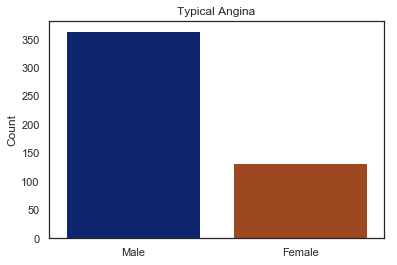

```python
ctarget_off=len(HD[(HD.Chest_pain_type=='typical angina')&(HD.Sex=='Male')])
ctarget_on=len(HD[(HD.Chest_pain_type=='typical angina')&(HD.Sex=='Female')])
sns.barplot(x=['Male','Female'],y=[ctarget_off,ctarget_on],palette='dark')
plt.ylabel('Count')
plt.title('Typical Angina')
plt.show()
```

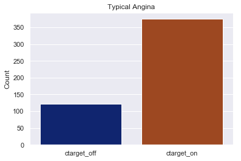

```python
ctarget_off=len(HD[(HD.Chest_pain_type=='typical angina')&(HD.target=='Normal')])
ctarget_on=len(HD[(HD.Chest_pain_type=='typical angina')&(HD.target=='Suffering')])
sns.barplot(x=['ctarget_off','ctarget_on'],y=[ctarget_off,ctarget_on],palette='dark')
plt.ylabel('Count')
plt.title('Typical Angina')
plt.show()
```

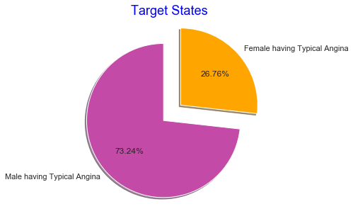

```python
ctarget_off=len(HD[(HD.Chest_pain_type=='typical angina')&(HD.Sex=='Male')])
ctarget_on=len(HD[(HD.Chest_pain_type=='typical angina')&(HD.Sex=='Female')])

colors = ['#C34BA7','orange']
plt.figure(figsize = (7,5))
plt.pie([(ctarget_off),(ctarget_on)],labels=['Male having Typical Angina','Female having Typical Angina'],colors=colors,explode =(0.1,0.2),startangle=90,shadow=True,autopct='%1.2f%%')
plt.title('Target States',color = 'blue',fontsize = 18)
plt.show()
```

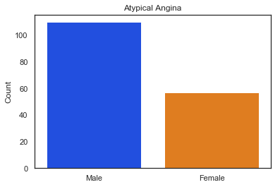

```python
ctarget_off=len(HD[(HD.Chest_pain_type=='atypical angina')&(HD.Sex=='Male')])
ctarget_on=len(HD[(HD.Chest_pain_type=='atypical angina')&(HD.Sex=='Female')])
sns.barplot(x=['Male','Female'],y=[ctarget_off,ctarget_on],palette='bright')
plt.ylabel('Count')
plt.title('Atypical Angina')
plt.show()
```

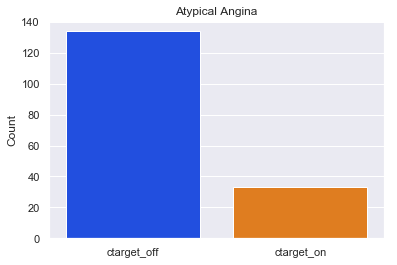

```python
ctarget_off=len(HD[(HD.Chest_pain_type=='atypical angina')&(HD.target=='Normal')])
ctarget_on=len(HD[(HD.Chest_pain_type=='atypical angina')&(HD.target=='Suffering')])
sns.barplot(x=['ctarget_off','ctarget_on'],y=[ctarget_off,ctarget_on],palette='bright')
plt.ylabel('Count')
plt.title('Atypical Angina')
plt.show()
```

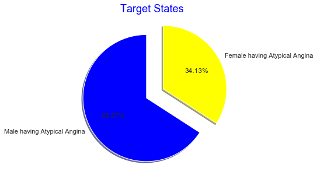

```python
ctarget_off=len(HD[(HD.Chest_pain_type=='atypical angina')&(HD.Sex=='Male')])
ctarget_on=len(HD[(HD.Chest_pain_type=='atypical angina')&(HD.Sex=='Female')])

colors = ['blue','yellow']
plt.figure(figsize = (7,5))
plt.pie([(ctarget_off),(ctarget_on)],labels=['Male having Atypical Angina','Female having Atypical Angina'],colors=colors,explode =(0.1,0.2),startangle=90,shadow=True,autopct='%1.2f%%')
plt.title('Target States',color = 'blue',fontsize = 18)
plt.show()
```

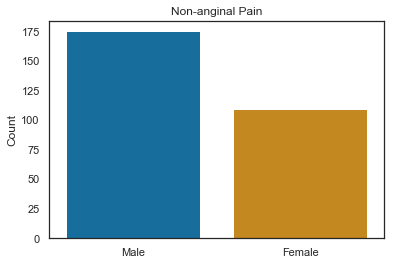

```python
ctarget_off=len(HD[(HD.Chest_pain_type=='non-anginal pain')&(HD.Sex=='Male')])
ctarget_on=len(HD[(HD.Chest_pain_type=='non-anginal pain')&(HD.Sex=='Female')])
sns.barplot(x=['Male','Female'],y=[ctarget_off,ctarget_on],palette='colorblind')
plt.ylabel('Count')
plt.title('Non-anginal Pain')
plt.show()
```

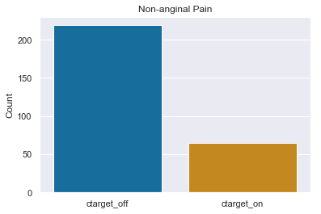

```python
ctarget_off=len(HD[(HD.Chest_pain_type=='non-anginal pain')&(HD.target=='Normal')])
ctarget_on=len(HD[(HD.Chest_pain_type=='non-anginal pain')&(HD.target=='Suffering')])
sns.barplot(x=['ctarget_off','ctarget_on'],y=[ctarget_off,ctarget_on],palette='colorblind')
plt.ylabel('Count')
plt.title('Non-anginal Pain')
plt.show()
```

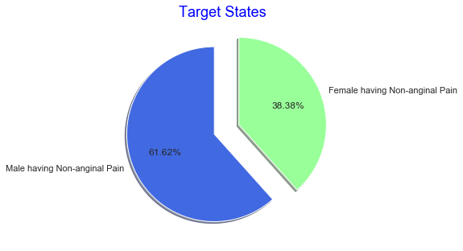

```python
ctarget_off=len(HD[(HD.Chest_pain_type=='non-anginal pain')&(HD.Sex=='Male')])
ctarget_on=len(HD[(HD.Chest_pain_type=='non-anginal pain')&(HD.Sex=='Female')])

colors = ['royalblue','#99ff99']
plt.figure(figsize = (7,5))
plt.pie([(ctarget_off),(ctarget_on)],labels=['Male having Non-anginal Pain','Female having Non-anginal Pain'],colors=colors,explode =(0.1,0.2),startangle=90,shadow=True,autopct='%1.2f%%')
plt.title('Target States',color = 'blue',fontsize = 18)
plt.show()
```

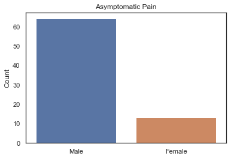

```python
ctarget_off=len(HD[(HD.Chest_pain_type=='asymptomatic')&(HD.Sex=='Male')])
ctarget_on=len(HD[(HD.Chest_pain_type=='asymptomatic')&(HD.Sex=='Female')])
sns.barplot(x=['Male','Female'],y=[ctarget_off,ctarget_on],palette='deep')
plt.ylabel('Count')
plt.title('Asymptomatic Pain')
plt.show()
```

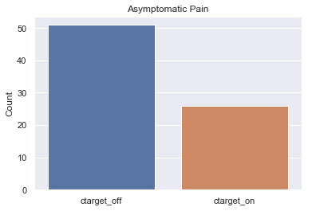

```python
ctarget_off=len(HD[(HD.Chest_pain_type=='asymptomatic')&(HD.target=='Normal')])
ctarget_on=len(HD[(HD.Chest_pain_type=='asymptomatic')&(HD.target=='Suffering')])
sns.barplot(x=['ctarget_off','ctarget_on'],y=[ctarget_off,ctarget_on],palette='deep')
plt.ylabel('Count')
plt.title('Asymptomatic Pain')
plt.show()
```

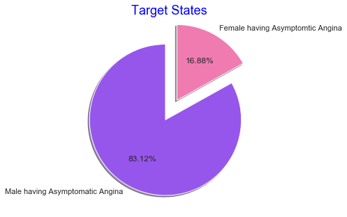

```python
ctarget_off=len(HD[(HD.Chest_pain_type=='asymptomatic')&(HD.Sex=='Male')])
ctarget_on=len(HD[(HD.Chest_pain_type=='asymptomatic')&(HD.Sex=='Female')])

colors = ['#9756EB','#EF7BB1']
plt.figure(figsize = (7,5))
plt.pie([(ctarget_off),(ctarget_on)],labels=['Male having Asymptomatic Angina','Female having Asymptomtic Angina'],colors=colors,explode =(0.1,0.2),startangle=90,shadow=True,autopct='%1.2f%%')
plt.title('Target States',color = 'blue',fontsize = 18)
plt.show()
```

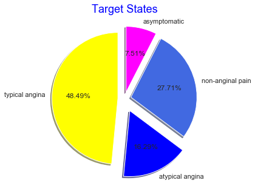

```python
ta=HD[HD.Chest_pain_type=='typical angina']
aa=HD[HD.Chest_pain_type =='atypical angina']
np=HD[HD.Chest_pain_type =='non-anginal pain']
a=HD[HD.Chest_pain_type =='asymptomatic']
colors = ['yellow','blue','royalblue','magenta']
plt.figure(figsize = (7,5))
plt.pie([len(ta),len(aa),len(np),len(a)],labels=['typical angina','atypical angina','non-anginal pain','asymptomatic'],colors=colors,explode =(0.1,0.2,0.1,0.1),startangle=90,shadow=True,autopct='%1.2f%%')
plt.title('Target States',color = 'blue',fontsize = 18)
plt.show()
```

# 3.5 MaximumHeartRateAchievedDataAnalysis

## What is the count of Maximum Heart Rate Achieved by People?

```python
HD.maximum_heart_rate_achieved.value_counts()               # Basic Count
```

```
162    35
160    31
163    29
152    28
173    28
144    26
132    26
150    25
125    25
143    23
169    22
172    21
140    21
156    21
142    19
```

[output cut: 47 more lines]

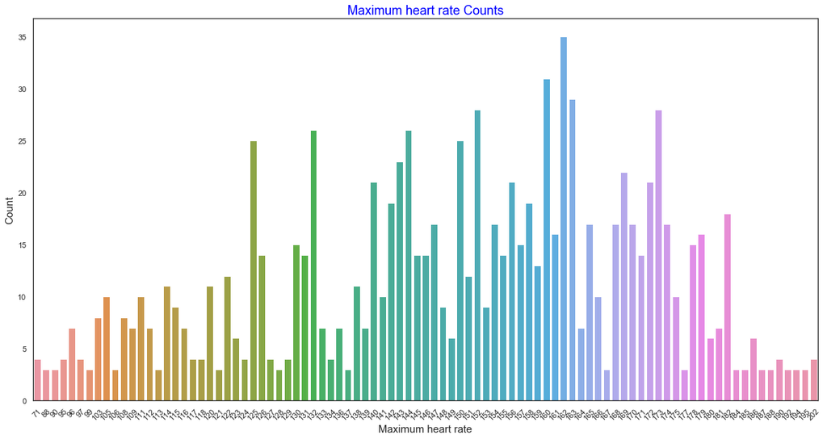

```python
plt.figure(figsize=(20,10))
sns.barplot(x=HD.maximum_heart_rate_achieved.value_counts().index,y=HD.maximum_heart_rate_achieved.value_counts().values)
plt.xlabel('Maximum heart rate',fontsize=15)
plt.ylabel('Count',fontsize=15)
plt.title('Maximum heart rate Counts',fontsize=18,color='blue')
plt.xticks(rotation=45)
plt.show()
```

```python
HD[HD.maximum_heart_rate_achieved == 162].count()
```

[output not shown]

```python
age_unique=sorted(HD.Age.unique())
age_maxHeartRate_values=HD.groupby('Age')['maximum_heart_rate_achieved'].count().values
mean_maxHeartRate=[]
for i,age in enumerate(age_unique):
    mean_maxHeartRate.append(sum(HD[HD['Age']==age].maximum_heart_rate_achieved)/age_maxHeartRate_values[i])
```

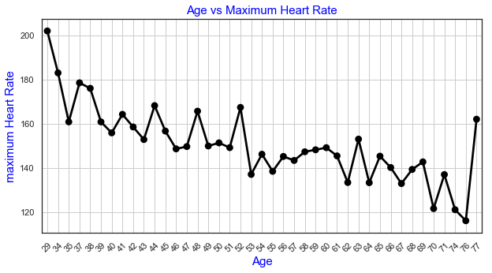

```python
plt.figure(figsize=(10,5))
sns.pointplot(x=age_unique,y=mean_maxHeartRate,color='black',alpha=0.8)
plt.xlabel('Age',fontsize = 15,color='blue')
plt.xticks(rotation=45)
plt.ylabel('maximum Heart Rate',fontsize = 15,color='blue')
plt.title('Age vs Maximum Heart Rate',fontsize = 15,color='blue')
plt.grid()
plt.show()
```

## What is the average Maximum Heart rate Achieved for different ages of people?

```python
age_range_maxHeartRate=HD.groupby('Age')['maximum_heart_rate_achieved'].mean()
```

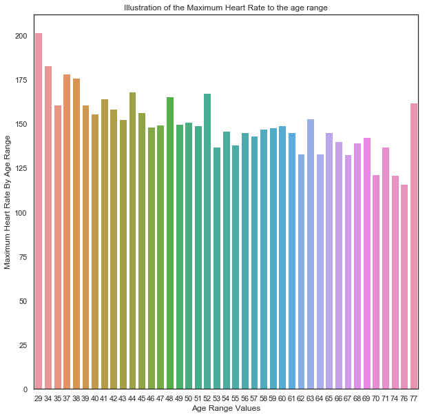

```python
plt.figure(figsize=(10,10))
sns.barplot(x=age_range_maxHeartRate.index,y=age_range_maxHeartRate.values)
plt.xlabel('Age Range Values')
plt.ylabel('Maximum Heart Rate By Age Range')
plt.title('Illustration of the Maximum Heart Rate to the age range')
plt.show()
```

```python
HD[HD.Age==29][["Age","maximum_heart_rate_achieved"]]
```

|  | Age | maximum_heart_rate_achieved |
| --- | --- | --- |
| 60 | 29 | 202 |
| 64 | 29 | 202 |
| 118 | 29 | 202 |
| 668 | 29 | 202 |

```python
chestPain_maxHeartRate=HD.groupby('Chest_pain_type')['maximum_heart_rate_achieved'].mean()
```

```python
chestPain_maxHeartRate
```

```
Chest_pain_type
asymptomatic        157.129870
atypical angina     162.179641
non-anginal pain    155.116197
typical angina      140.052314
Name: maximum_heart_rate_achieved, dtype: float64
```

## What is the Average Maximum Heart rate Achieved for different Chest Pain Types of people?

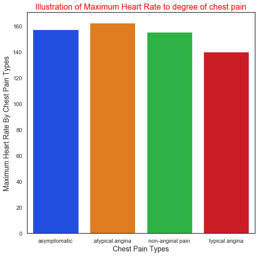

```python
plt.figure(figsize=(8,8))
sns.barplot(x=chestPain_maxHeartRate.index,y=chestPain_maxHeartRate.values,palette='bright')
plt.xlabel('Chest Pain Types',fontsize=14)
plt.ylabel('Maximum Heart Rate By Chest Pain Types',fontsize=14)
plt.title('Illustration of Maximum Heart Rate to degree of chest pain',fontsize=16,color='red')
plt.show()
```

# 3.6 CardiacArrestDataAnalysis

## What is the count of Cardiac Arrest affected people?

```python
HD.Cardiac_Arrest.value_counts()
```

```
1st    578
2nd    226
3rd    134
4th     69
5th     18
Name: Cardiac_Arrest, dtype: int64
```

## What is the percentage of people having different types of Cardiac Arrest?

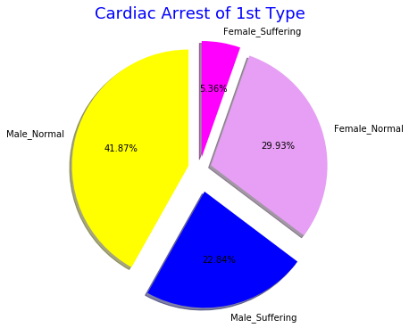

```python
a=len(HD[(HD.Cardiac_Arrest=='1st')&(HD.target=='Normal')&(HD.Sex=='Male')])
b=len(HD[(HD.Cardiac_Arrest=='1st')&(HD.target=='Suffering')&(HD.Sex=='Male')])


c=len(HD[(HD.Cardiac_Arrest=='1st')&(HD.target=='Normal')&(HD.Sex=='Female')])
d=len(HD[(HD.Cardiac_Arrest=='1st')&(HD.target=='Suffering')&(HD.Sex=='Female')])


colors = ['yellow','blue','#E69FF4','magenta']
plt.figure(figsize = (8,6))
plt.pie([(a),(b),(c),(d)],labels=['Male_Normal','Male_Suffering','Female_Normal','Female_Suffering'],colors=colors,explode =(0.1,0.2,0.1,0.1),startangle=90,shadow=True,autopct='%1.2f%%')
plt.title('Cardiac Arrest of 1st Type',color = 'blue',fontsize = 18)
plt.show()
```

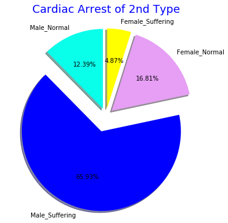

```python
a=len(HD[(HD.Cardiac_Arrest=='2nd')&(HD.target=='Normal')&(HD.Sex=='Male')])
b=len(HD[(HD.Cardiac_Arrest=='2nd')&(HD.target=='Suffering')&(HD.Sex=='Male')])


c=len(HD[(HD.Cardiac_Arrest=='2nd')&(HD.target=='Normal')&(HD.Sex=='Female')])
d=len(HD[(HD.Cardiac_Arrest=='2nd')&(HD.target=='Suffering')&(HD.Sex=='Female')])


colors = ['#0AFFEB','blue','#E69FF4','yellow']
plt.figure(figsize = (8,6))
plt.pie([(a),(b),(c),(d)],labels=['Male_Normal','Male_Suffering','Female_Normal','Female_Suffering'],colors=colors,explode =(0.1,0.2,0.1,0.1),startangle=90,shadow=True,autopct='%1.2f%%')
plt.title('Cardiac Arrest of 2nd Type',color = 'blue',fontsize = 18)
plt.show()
```

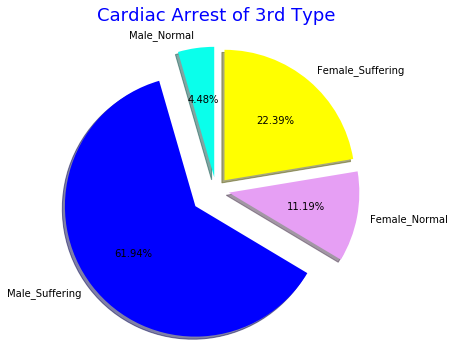

```python
a=len(HD[(HD.Cardiac_Arrest=='3rd')&(HD.target=='Normal')&(HD.Sex=='Male')])
b=len(HD[(HD.Cardiac_Arrest=='3rd')&(HD.target=='Suffering')&(HD.Sex=='Male')])


c=len(HD[(HD.Cardiac_Arrest=='3rd')&(HD.target=='Normal')&(HD.Sex=='Female')])
d=len(HD[(HD.Cardiac_Arrest=='3rd')&(HD.target=='Suffering')&(HD.Sex=='Female')])


colors = ['#0AFFEB','blue','#E69FF4','yellow']
plt.figure(figsize = (8,6))
plt.pie([(a),(b),(c),(d)],labels=['Male_Normal','Male_Suffering','Female_Normal','Female_Suffering'],colors=colors,explode =(0.1,0.2,0.1,0.1),startangle=90,shadow=True,autopct='%1.2f%%')
plt.title('Cardiac Arrest of 3rd Type',color = 'blue',fontsize = 18)
plt.show()
```

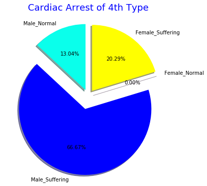

```python
x=len(HD[(HD.Cardiac_Arrest=='4th')&(HD.target=='Normal')&(HD.Sex=='Male')])
y=len(HD[(HD.Cardiac_Arrest=='4th')&(HD.target=='Suffering')&(HD.Sex=='Male')])


z=len(HD[(HD.Cardiac_Arrest=='4th')&(HD.target=='Normal')&(HD.Sex=='Female')])
w=len(HD[(HD.Cardiac_Arrest=='4th')&(HD.target=='Suffering')&(HD.Sex=='Female')])


colors = ['#0AFFEB','blue','#E69FF4','yellow']
plt.figure(figsize = (8,6))
plt.pie([x,y,z,w],labels=['Male_Normal','Male_Suffering','Female_Normal','Female_Suffering'],colors=colors,explode =(0.1,0.2,0.1,0.1),startangle=90,shadow=True,autopct='%1.2f%%')
plt.title('Cardiac Arrest of 4th Type',color = 'blue',fontsize = 18)
plt.show()
```

```python
HD[(HD.Cardiac_Arrest=='4th') & (HD.Sex=='Female') & (HD.target=='Normal')].count()
```

```
Age                                0
Sex                                0
Chest_pain_type                    0
resting_blood_pressure             0
cholestoral                        0
fasting_blood_sugar                0
resting_cardiographic_results      0
maximum_heart_rate_achieved        0
exercise_induced_angina            0
depression_induced_by_excercise    0
Cardiac_Arrest                     0
Thalassemia                        0
target                             0
dtype: int64
```

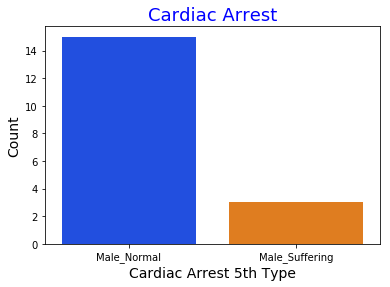

```python
ctarget_off=len(HD[(HD.Cardiac_Arrest=='5th')&(HD.target=='Normal')&(HD.Sex=='Male')])
ctarget_on=len(HD[(HD.Cardiac_Arrest=='5th')&(HD.target=='Suffering')&(HD.Sex=='Male')])
sns.barplot(x=['Male_Normal','Male_Suffering'],y=[ctarget_off,ctarget_on],palette='bright')
plt.xlabel('Cardiac Arrest 5th Type',fontsize=14)
plt.ylabel('Count',fontsize=14)
plt.title('Cardiac Arrest',fontsize=18,color='blue')
plt.show()
```

```python
# There is no Female candidate in Cardiac Arrest 5th type
```

## What is the count of people(Male & Female) affected by Cardiac Arrest?

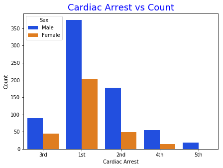

```python
plt.figure(figsize = (7,5))
sns.countplot(HD.Cardiac_Arrest,hue=HD.Sex,palette='bright')
plt.xlabel('Cardiac Arrest')
plt.ylabel('Count')
plt.title('Cardiac Arrest vs Count',fontsize=18,color='blue')
plt.show()
```

## How much people(Male & female) of different ages are having Chest Pain and affected by Cardiac Arrest?

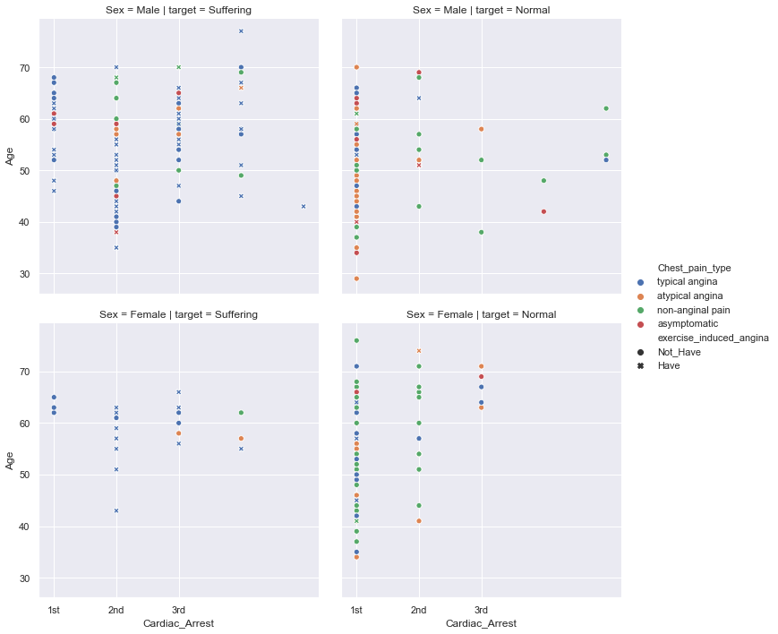

```python
sns.set(style="darkgrid")
fig=plt.figure(figsize=(20,20))
sns.relplot(x="Cardiac_Arrest",y="Age",hue='Chest_pain_type', style='exercise_induced_angina', col='target', row='Sex', data=HD)
plt.figure(dpi=5000)
```

# 3.7 ThalassemiaDataAnalysis

## What is the count of male and female having different types of Thalassemia?

```python
HD.Thalassemia.value_counts()
```

```
Fixed_Defect         544
Reversable_Defect    410
Normal                71
Name: Thalassemia, dtype: int64
```

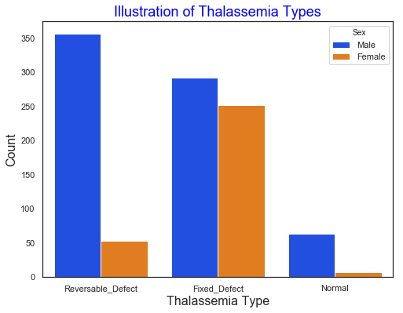

```python
plt.figure(figsize=(8,6))
sns.countplot(HD.Thalassemia,hue=HD.Sex,palette='bright')
plt.title('Illustration of Thalassemia Types',fontsize=18,color='blue')
plt.xlabel('Thalassemia Type',fontsize=16)
plt.ylabel('Count',fontsize=16)
plt.show()
```

# 3.6 TargetDataAnalysis

## What is the count of Male and Female having and not having Heart Disease?

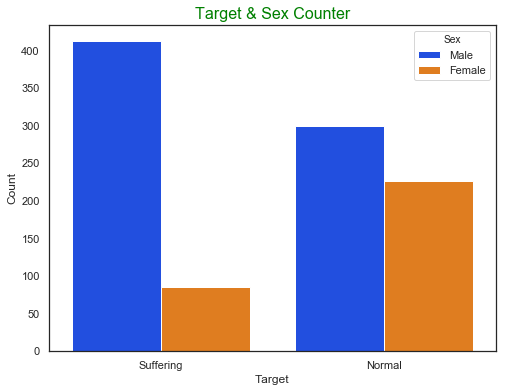

```python
plt.figure(figsize=(8,6))
sns.countplot(HD.target,hue=HD.Sex,palette='bright')
plt.xlabel('Target')
plt.ylabel('Count')
plt.title('Target & Sex Counter',fontsize=16,color='green')
plt.show()
```

```python
age_target_1=[]
age_target_0=[]
for age in HD.Age.unique():
    age_target_1.append(len(HD[(HD['Age']==age)&(HD.target=='Normal')]))
    age_target_0.append(len(HD[(HD['Age']==age)&(HD.target=='Suffering')]))
```

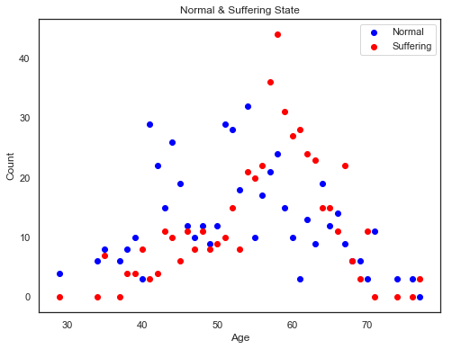

```python
plt.figure(figsize=(8,6))
plt.scatter(x=HD.Age.unique(),y=age_target_1,color='blue',label='Normal')
plt.scatter(x=HD.Age.unique(),y=age_target_0,color='red',label='Suffering')
plt.legend(loc='upper right',frameon=True)
plt.xlabel('Age')
plt.ylabel('Count')
plt.title('Normal & Suffering State')
plt.show()
```

## Illustration of Age vs Target

```python
HD.loc[HD['target'] == 'Normal', 'target'] =1
HD.loc[HD['target'] == 'Suffering', 'target'] = 0
age_unique=sorted(HD.Age.unique())
age_target_values=HD.groupby('Age')['target'].count().values
target_values=[]
for i,age in enumerate(age_unique):
    target_values.append(sum(HD[HD['Age']==age].target)/age_target_values[i])
```

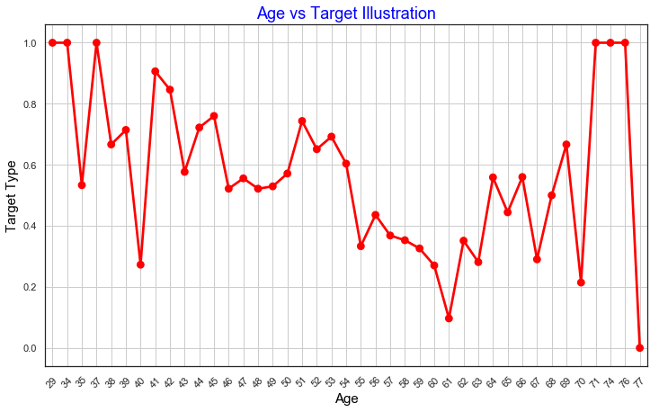

```python
plt.figure(figsize=(12,7))
sns.pointplot(x=age_unique,y=target_values,color='red',alpha=0.8)
plt.xlabel('Age',fontsize = 15,color='black')
plt.xticks(rotation=45)
plt.ylabel('Target Type',fontsize = 15,color='black')
plt.title('Age vs Target Illustration',fontsize = 18,color='blue')
plt.grid()
plt.show()
HD.loc[HD['target'] == 1, 'target'] = 'Normal'
HD.loc[HD['target'] == 0, 'target'] = 'Suffering'
```

## What is the percentage of Male and Female are suffering and not suffering from Heart Disease?

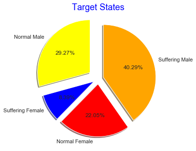

```python
#x=HD[HD.target=='Normal']
#y=HD[HD.target=='Suffering']


x=len(HD[(HD.target=='Normal')&(HD.Sex=='Male')])
y=len(HD[(HD.target=='Suffering')&(HD.Sex=='Female')])
z=len(HD[(HD.target=='Normal')&(HD.Sex=='Female')])
w=len(HD[(HD.target=='Suffering')&(HD.Sex=='Male')])

colors = ['yellow','blue','red','orange']
plt.figure(figsize = (7,5))
plt.pie([(x),(y),(z),(w)],labels=['Normal Male','Suffering Female','Normal Female','Suffering Male'],colors=colors,explode =(0.2,0.1,0.1,0.1),startangle=90,shadow=True,autopct='%1.2f%%')
plt.title('Target States',color = 'blue',fontsize = 18)
plt.show()
```